# MY472 Final Assignment

2023-12-28

My GitHub repository can be found [here](https://github.com/L-hub23/MY472_Assignment4).

## Introduction

This research project aims to answer the following research question: *What, if any, characteristics and factors discriminate MPs who tend to ask questions about economic issues from MPs who tend to ask questions about health and welfare issues?*

Both topics are broad and are often referenced in relation to other things; relevant questions may therefore be asked to various governmental departments. However, since the purpose of this research is not to get the total number of questions asked for each topic, the analysis will be restricted to only questions for the Department of Health and Social Care (DHS) and the Department for Business and Trade (DBT). The primary focus of questions for these departments can be assumed to be relevant for this research.

## Data

The DBT was only established in February 2023, and its predecessor was also responsible for topics not relevant for this research project. Therefore, questions were sampled between February 2023 and December 2023. Overall, there were 175 oral questions answered by the DHS in this time period. Oral questions are only answered every few weeks, and since the DBT had one more answering session than the DHS, the final answering session of the DBT was not considered so there were 175 questions sampled for each department.

Since written questions are answered throughout the year and to ensure comparability between frequency of oral and written questions to the specified departments between MPs, 175 written questions were sampled from the specified time frame. In order to avoid differing results due to outside events, 35 written questions were sampled for each department for each month in which an oral question session took place. The data was accessed through the UK Parliament API.

Also considered was each MP’s age, position on the economic left-right scale and their constituency’s median wage.

Information on the MP’s ages was taken from their Wikipedia pages, [based on a list of MPs elected in 2019](https://en.wikipedia.org/wiki/List_of_MPs_elected_in_the_2019_United_Kingdom_general_election). In the case of age being given as a range, the smaller number was taken. 31 MPs were not captured by this method, 22 of which are Labour MPs. For 20 MPs, this is because they were elected in by-elections during the term. The last 11 have different spellings of their names, which means matching was not possible.

The MPs positions on the left-right scale were taken from a dataset created by [Royal Holloway, University of London and Survation](http://www.mpsleftright.co.uk). In this dataset, 42 MPs are missing, these were not included in the analysis. The dataset is based on comparisons between pairs of MPs, and a lower score signifies a more left-leaning MP.

Constituency Median Wage was retrieved from [a dataset provided by the House of Commons based on data from the Office for National Statistics](https://commonslibrary.parliament.uk/constituency-data-wages/). The constituency Weston-super-Mare is missing and was not considered.

## Analysis

### Party

The following bar plot shows the absolute number of Health/Welfare and Business/Trade questions asked by MPs of each party.

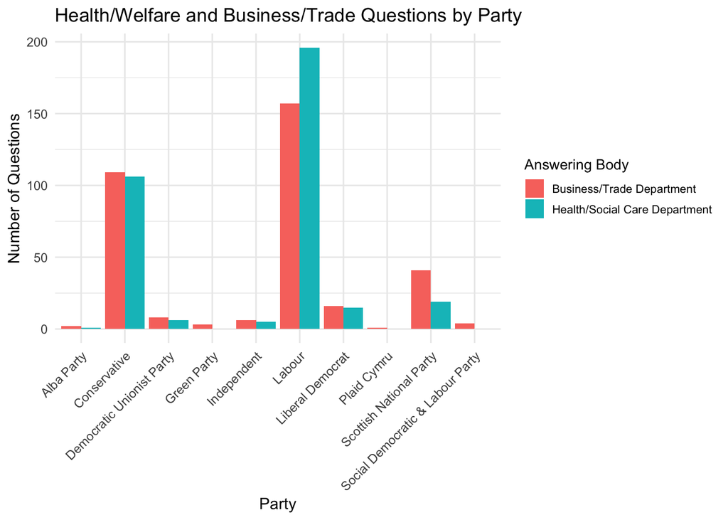

The biggest parties ask the most questions for both topics. Interestingly, Labour MPs asked notably more questions on both Health/Welfare and Business/Trade even though there are currently more Conservative MPs. Presumably either be due to Labour being a left-wing party or because as opposition, Labour MPs have a higher incentive to question the government’s actions.

### Constituency

#### Geographical location

The following two maps show the number of questions on Health/Welfare and Business/Trade, respectively, by the MP of each constituency, shown as hexagons.

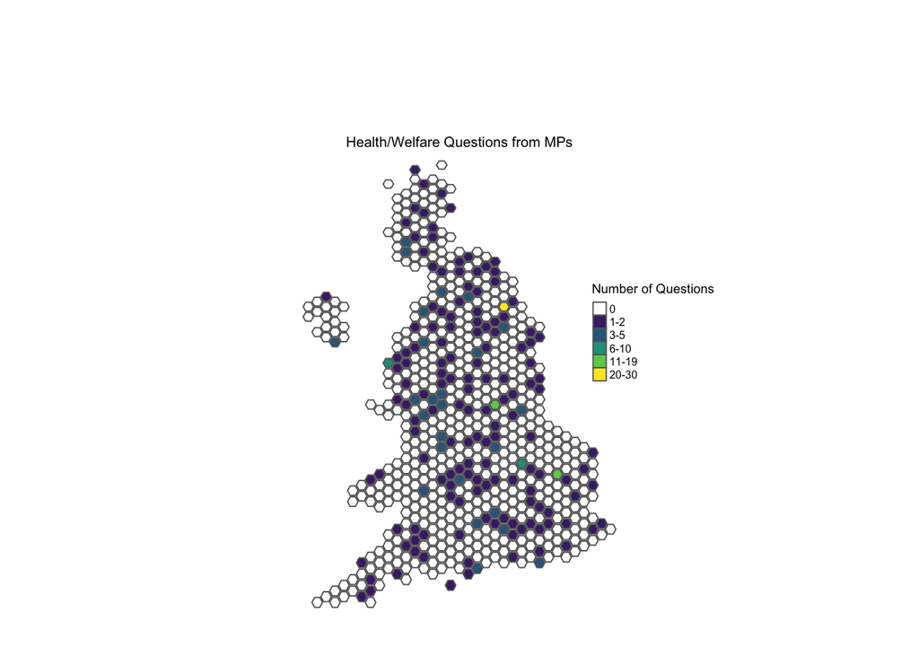

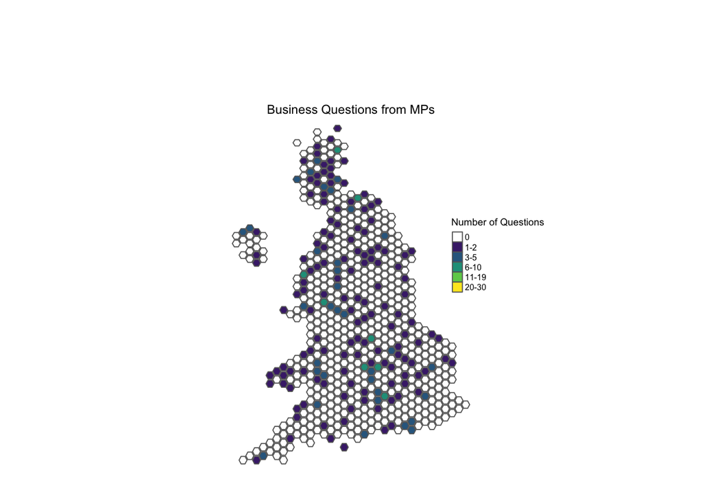

Interesting to note is that while Health/Welfare questions were primarily asked by MPs from Northern England as well as the Midlands, Business/Trade questions were asked by most MPs from Wales and Scotland, potentially because health systems differ slightly between countries in the UK.

#### Median Wage

The following two scatterplots show the relationship between the median wages of MP constituencies and the number of questions asked to Health/Welfare and Business/Trade departments respectively.

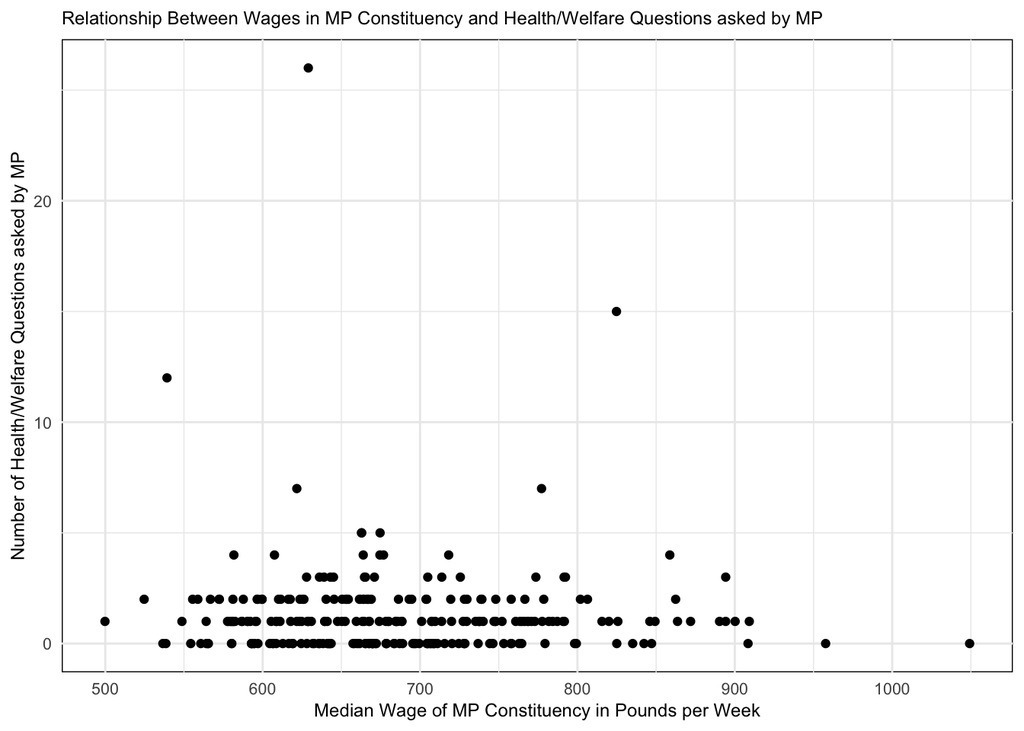

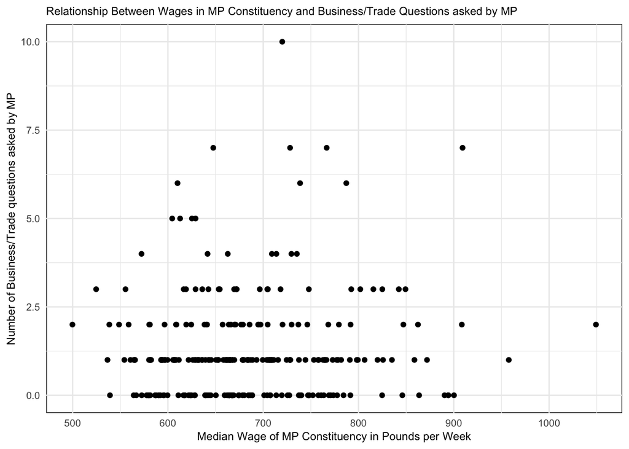

Constituency wages do not seem to influence the frequency of questions asked for either department. Even though the data is more scattered for Business/Trade related questions, this only indicates that there are more MPs across all constituencies that asked several questions on economic matters, while for welfare, MPs generally ask less questions, with a few notable outliers.

### Age and Left-Right Alignment

For the aspects of both age and left-right alignment, the following scatterplots show a similar trend.

#### Age

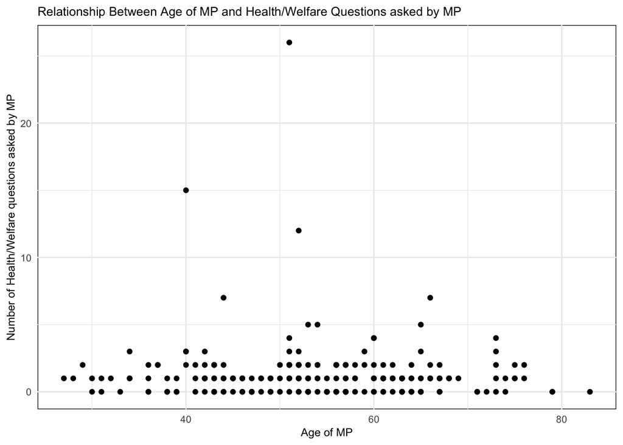

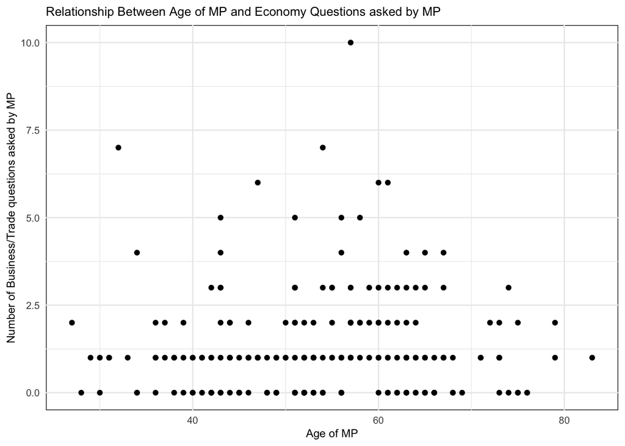

#### Political Left-Right Alignment

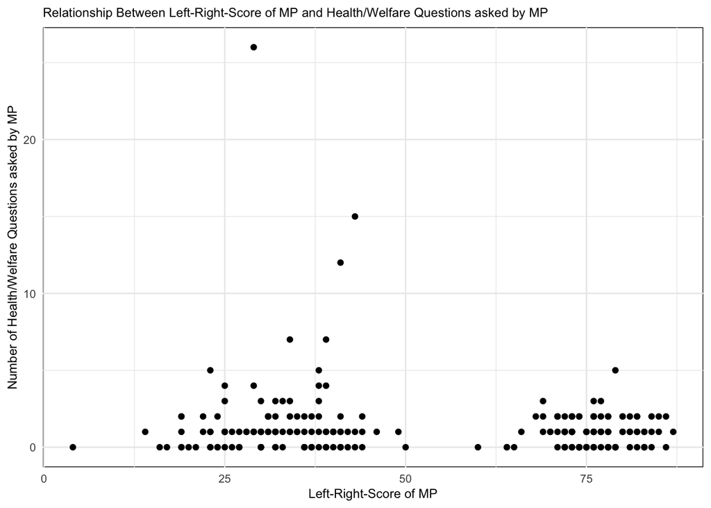

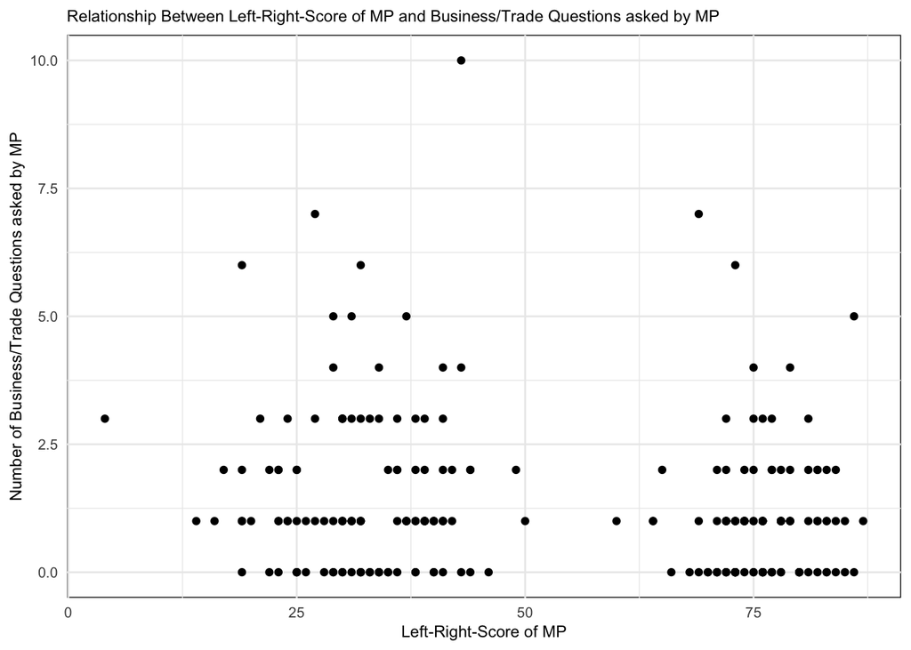

In conclusion, it can be said that MPs who tend to ask questions about welfare issues tend to be from the Labour Party, while Scottish MPs tend to ask more questions about economic issues.

## References

Constituency data: wages (2023). House of Commons [Data set].

Hanretty, C. (2023). *Estimates of MP positions* [Data set]. Royal Holloway, University of London & Survation.

List of MPs elected in the 2019 United Kingdom general election (2023, December 28). In *Wikipedia*. https://en.wikipedia.org/wiki/List_of_MPs_elected_in_the_2019_United_Kingdom_general_election

## Appendix: All code in this assignment

```r
knitr::opts_chunk$set(echo = FALSE, warning = FALSE, message = FALSE)
library("httr")
library("jsonlite")
library("tidyverse")
library("tibble")
library("readxl")
library("parlitools")
library("xml2")
library("rvest")
library("DBI")
library("RSQLite")
library("tmap")
library("sf")

# Questions have to be requested from the API in three steps since there is a maximum of 100 questions per request
# Each request contains the maximum number of answering sessions with the department in question where the number of questions does not exceed 100
# This was done so no question is counted twice and no question is left out

# get first JSON at start of time frame of interest, only questions answered by Department of Health and Welfare
health_qs_JSON_1 <- "https://oralquestionsandmotions-api.parliament.uk/oralquestions/list?parameters.answeringDateStart=2023-02-07&parameters.answeringDateEnd=2023-04-25&parameters.answeringBodyIds=17&parameters.take=100"

# extract the response as a tibble without row names
health_qs_1 <- fromJSON(health_qs_JSON_1)
rownames(health_qs_1) <- NULL
health_tibble_1 <- as_tibble(health_qs_1$Response)

#repeat process for the rest of the answering sessions in the time frame of interest:
health_qs_JSON_2 <- "https://oralquestionsandmotions-api.parliament.uk/oralquestions/list?parameters.answeringDateStart=2023-04-26&parameters.answeringDateEnd=2023-07-11&parameters.answeringBodyIds=17&parameters.take=100"

health_qs_2 <- fromJSON(health_qs_JSON_2)
rownames(health_qs_2) <- NULL
health_tibble_2 <- as_tibble(health_qs_2$Response)

health_qs_JSON_3 <- "https://oralquestionsandmotions-api.parliament.uk/oralquestions/list?parameters.answeringDateStart=2023-07-12&parameters.answeringDateEnd=2023-10-17&parameters.answeringBodyIds=17&parameters.take=100"

health_qs_3 <- fromJSON(health_qs_JSON_3)
rownames(health_qs_3) <- NULL
health_tibble_3 <- as_tibble(health_qs_3$Response)

# Combine into one table
oral_health_qs <- bind_rows(health_tibble_1, health_tibble_2, health_tibble_3)


# repeat process for questions answered by Department for Business and Trade
econ_qs_JSON_1 <- "https://oralquestionsandmotions-api.parliament.uk/oralquestions/list?parameters.answeringDateStart=2023-02-07&parameters.answeringDateEnd=2023-05-18&parameters.answeringBodyIds=214&parameters.take=100"

econ_qs_1 <- fromJSON(econ_qs_JSON_1)
rownames(econ_qs_1) <- NULL
econ_tibble_1 <- as_tibble(econ_qs_1$Response)

econ_qs_JSON_2 <- "https://oralquestionsandmotions-api.parliament.uk/oralquestions/list?parameters.answeringDateStart=2023-05-19&parameters.answeringDateEnd=2023-09-14&parameters.answeringBodyIds=214&parameters.take=100"

# extract the response as a tibble without row names
econ_qs_2 <- fromJSON(econ_qs_JSON_2)
rownames(econ_qs_2) <- NULL
econ_tibble_2 <- as_tibble(econ_qs_2$Response)

econ_qs_JSON_3 <- "https://oralquestionsandmotions-api.parliament.uk/oralquestions/list?parameters.answeringDateStart=2023-09-15&&parameters.answeringBodyIds=214&parameters.take=100"

econ_qs_3 <- fromJSON(econ_qs_JSON_3)
rownames(econ_qs_3) <- NULL
econ_tibble_3 <- as_tibble(econ_qs_3$Response)

# Combine into one table
oral_econ_qs <- bind_rows(econ_tibble_1, econ_tibble_2, econ_tibble_3)

#Unpacking data frames with information about the asking MP:
oral_health_qs <- oral_health_qs %>%
  unnest(AskingMember, names_sep = "_")
oral_econ_qs <- oral_econ_qs %>%
  unnest(AskingMember, names_sep = "_")

# Combining health and economy questions into one table
oral_qs <- bind_rows(oral_health_qs, oral_econ_qs)

#Getting rid of unnecessary columns; question topic can be discerned by answering body:
oral_qs <- select(oral_qs, -Id, -Status, -Number, -TabledWhen, -RemovedFromToBeAskedWhen, -DeclarableInterestDetail, -HansardLink, -UIN, -AskingMember_MnisId, -AskingMember_PimsId, -AskingMember_ListAs, -AskingMember_PartyId, -AskingMember_PartyColour, -AskingMember_PhotoUrl, -AnsweringMinister, -AskingMemberId, -AnsweringMinisterId, -AnsweringMinisterTitle, -QuestionText, -QuestionType, -AskingMember_Status, -AnsweringWhen)

oral_qs <- rename(oral_qs, MP = AskingMember_Name, Constituency = AskingMember_Constituency, Party = AskingMember_Party)
# Getting data on written questions
health_written_JSON_1 <- "https://questions-statements-api.parliament.uk/api/writtenquestions/questions?answeredWhenFrom=2023-03-01&answeredWhenTo=2023-03-31&questionStatus=AllQuestions&includeWithdrawn=true&expandMember=true&answeringBodies=17&house=Commons&take=35"

health_written_1 <- fromJSON(health_written_JSON_1)
health_written_1 <- as_tibble(health_written_1$results)
health_written_1 <- health_written_1$value

# repeat process for all months the Department of Health and Welfare has oral answering sessions
health_written_JSON_2 <- "https://questions-statements-api.parliament.uk/api/writtenquestions/questions?answeredWhenFrom=2023-04-01&answeredWhenTo=2023-04-30&questionStatus=AllQuestions&includeWithdrawn=true&expandMember=true&answeringBodies=17&house=Commons&take=35"

health_written_2 <- fromJSON(health_written_JSON_2)

health_written_2 <- as_tibble(health_written_2$results)

health_written_2 <- health_written_2$value

health_written_JSON_3 <- "https://questions-statements-api.parliament.uk/api/writtenquestions/questions?answeredWhenFrom=2023-06-01&answeredWhenTo=2023-06-30&questionStatus=AllQuestions&includeWithdrawn=true&expandMember=true&answeringBodies=17&house=Commons&take=35"

health_written_3 <- fromJSON(health_written_JSON_3)

health_written_3 <- as_tibble(health_written_3$results)

health_written_3 <- health_written_3$value


health_written_JSON_4 <- "https://questions-statements-api.parliament.uk/api/writtenquestions/questions?answeredWhenFrom=2023-07-01&answeredWhenTo=2023-07-31&questionStatus=AllQuestions&includeWithdrawn=true&expandMember=true&answeringBodies=17&house=Commons&take=35"

health_written_4 <- fromJSON(health_written_JSON_4)

health_written_4 <- as_tibble(health_written_4$results)

health_written_4 <- health_written_4$value
```

```r
health_written_JSON_5 <- "https://questions-statements-api.parliament.uk/api/writtenquestions/questions?answeredWhenFrom=2023-10-01&answeredWhenTo=2023-10-31&questionStatus=AllQuestions&includeWithdrawn=true&expandMember=true&answeringBodies=17&house=Commons&take=35"

health_written_5 <- fromJSON(health_written_JSON_5)

health_written_5 <- as_tibble(health_written_5$results)

health_written_5 <- health_written_5$value


# combine tables:
written_health_qs <- bind_rows(health_written_1, health_written_2, health_written_3, health_written_4, health_written_5)


# repeat process for questions for department of business and trade
econ_written_JSON_1 <- "https://questions-statements-api.parliament.uk/api/writtenquestions/questions?answeredWhenFrom=2023-03-01&answeredWhenTo=2023-03-31&questionStatus=AllQuestions&includeWithdrawn=true&expandMember=true&answeringBodies=214&house=Commons&take=35"

econ_written_1 <- fromJSON(econ_written_JSON_1)

econ_written_1 <- as_tibble(econ_written_1$results)

econ_written_1 <- econ_written_1$value


econ_written_JSON_2 <- "https://questions-statements-api.parliament.uk/api/writtenquestions/questions?answeredWhenFrom=2023-05-01&answeredWhenTo=2023-05-31&questionStatus=AllQuestions&includeWithdrawn=true&expandMember=true&answeringBodies=214&house=Commons&take=35"

econ_written_2 <- fromJSON(econ_written_JSON_2)

econ_written_2 <- as_tibble(econ_written_2$results)

econ_written_2 <- econ_written_2$value

econ_written_JSON_3 <- "https://questions-statements-api.parliament.uk/api/writtenquestions/questions?answeredWhenFrom=2023-06-01&answeredWhenTo=2023-06-30&questionStatus=AllQuestions&includeWithdrawn=true&expandMember=true&answeringBodies=214&house=Commons&take=35"

econ_written_3 <- fromJSON(econ_written_JSON_3)

econ_written_3 <- as_tibble(econ_written_3$results)

econ_written_3 <- econ_written_3$value


econ_written_JSON_4 <- "https://questions-statements-api.parliament.uk/api/writtenquestions/questions?answeredWhenFrom=2023-09-01&answeredWhenTo=2023-09-30&questionStatus=AllQuestions&includeWithdrawn=true&expandMember=true&answeringBodies=214&house=Commons&take=35"

econ_written_4 <- fromJSON(econ_written_JSON_4)

econ_written_4 <- as_tibble(econ_written_4$results)

econ_written_4 <- econ_written_4$value


econ_written_JSON_5 <- "https://questions-statements-api.parliament.uk/api/writtenquestions/questions?answeredWhenFrom=2023-11-01&answeredWhenTo=2023-11-30&questionStatus=AllQuestions&includeWithdrawn=true&expandMember=true&answeringBodies=214&house=Commons&take=35"

econ_written_5 <- fromJSON(econ_written_JSON_5)

econ_written_5 <- as_tibble(econ_written_5$results)

econ_written_5 <- econ_written_5$value


# combine tables:
written_econ_qs <- bind_rows(econ_written_1, econ_written_2, econ_written_3, econ_written_4, econ_written_5)

#Unpacking data frames with information about the asking MP:
written_health_qs <- written_health_qs %>%
  unnest(askingMember, names_sep = "_")
written_econ_qs <- written_econ_qs %>%
  unnest(askingMember, names_sep = "_")

#combine tables for both topics into one table
written_qs <- bind_rows(written_health_qs, written_econ_qs)

# Getting rid of unnecessary columns
written_qs <- select(written_qs, -id, -askingMemberId, -askingMember_id, -askingMember_listAs, -askingMember_partyColour, -
askingMember_partyAbbreviation, -
askingMember_thumbnailUrl, -house, -memberHasInterest, -uin, -isWithdrawn, -isNamedDay, -groupedQuestions, -answerIsHolding, -answerIsCorrection, -answeringMemberId, -answeringMember, -correctingMemberId, -correctingMember, -answerText, -originalAnswerText, -comparableAnswerText, -dateAnswerCorrected, -dateHoldingAnswer, -attachmentCount, -heading, - attachments, -groupedQuestionsDates, -
dateTabled, -dateForAnswer, -
questionText, -dateAnswered)

written_qs <- rename(written_qs, MP =
askingMember_name, Constituency = askingMember_memberFrom, Party = askingMember_party, AnsweringBodyId = answeringBodyId, AnsweringBody =
answeringBodyName) #ensure uniform column names
# Add indicator if question was written or oral
oral_qs <- oral_qs %>%
  mutate(QuestionType = "Oral")
written_qs <- written_qs %>%
  mutate(QuestionType = "Written")

#Combine written and oral question tables into one
oral_written_qs <- bind_rows(oral_qs, written_qs)

# removing titles to ensure uniformity of name formats
oral_written_qs$MP <- gsub("Dr\ |Mr\ |Ms\ |Mrs\ |Dame\ |Sir\ ", "", oral_written_qs$MP)

# Get vector with names of asking MPs and their constituencies
AskingMPs <- unique(oral_written_qs$MP)
RelevantConstituencies <- unique(oral_written_qs$Constituency)
db <- dbConnect(RSQLite::SQLite(), dbname = "database/ParliamentQuestions.sqlite")
dbWriteTable(db, "All_Questions", oral_written_qs)
url <- "https://en.wikipedia.org/wiki/List_of_MPs_elected_in_the_2019_United_Kingdom_general_election"

  # Extracting HTML:
mp_table_html <- read_html(url) %>% html_nodes(xpath = '//*[@id="elected-mps"]')

  # Creating table:
mp_table <- mp_table_html %>% html_table()

#removing unnecessary columns and source row, improving column names:
mp_table_cleaned <- mp_table[[1]] %>%
                    select(-`Party of incumbentbefore election`, -`Party of incumbentafter election`)
mp_table_cleaned <- mp_table_cleaned %>%
                    rename(MP = `Member returned`)
mp_table_cleaned <- mp_table_cleaned[-651, ]

mp_table_filtered <- mp_table_cleaned %>% #filtering for only relevant MPs
                  filter(MP %in% AskingMPs)

missing_mps <- oral_written_qs$MP %>% #filtering for missing MPs
                  filter(!MP %in% mp_table_filtered$MP)

# Adding URLs
URL <- c()
for (member in mp_table_filtered$MP) {
  nodes <- mp_table_html %>%
    html_nodes(xpath = paste0('//a[text()="', member, '"]'))
  link <- nodes[[1]] %>% html_attr("href")
  URL <- c(URL, link)
}
URL <- paste0("https://en.wikipedia.org", URL)
mp_table_filtered$URL <- URL

# getting age from MPs that asked a written or oral question ONLY
info_extraction <- function(df) {
  # Setting up empty vectors for the elements of interest:
  Age <- c()
  for (URL in 1:nrow(df)) {
    info_labels <- c()
    info_data <- c()
    URL <- df$URL[URL] # iterating over MP page URLs
    current_html <- read_html(URL)
    # setting up access to content of infobox labels and data:
    infoboxlabel_html <- current_html %>% html_nodes(".infobox-label")
    infoboxdata_html <- current_html %>% html_nodes(".infobox-data")
    labels <- infoboxlabel_html %>% html_text()
    data <- infoboxdata_html %>% html_text()
    info_labels <- c(labels)
    info_data <- c(data)
    # extracting age:
    birthdate <- info_data[info_labels == "Born"]
    current_age <- str_extract(birthdate, "age\\s(\\d+)(-\\d+)?")
    if (length(current_age) > 0) {
      current_age <- gsub("[^0-9-]", "", current_age)
      if (grepl("-", current_age)) {
      # If it's a range, take the first value
        range_values <- as.numeric(strsplit(current_age, "-")[[1]])
        current_age <- range_values[1]
      } else {
      # If not a range, convert to integer
        current_age <- as.numeric(str_extract(current_age, "\\d+"))
      }
    } else {
      current_age <- NA
    }
    Age <- c(Age, current_age)
    Sys.sleep(2)
  }
  return(Age)
}
```

```r
Age <- info_extraction(mp_table_filtered)
mp_table_filtered$Age <- Age

mp_table_filtered <- select(mp_table_filtered, -Notes)

dbWriteTable(db, "MP_Ages", mp_table_filtered)
mp_leftright <- read_xlsx("data/mpsleftright_excel.xlsx", sheet = "MP values")

# select only necessary columns:
mp_leftright <- select(mp_leftright, Name, Constituency, PCON22CD, Party, Value, Rank)

# ensure identical column names
mp_leftright <- rename(mp_leftright, MP = Name, Constituency_ID = PCON22CD)

capitalize_names <- function(name) {
  words <- strsplit(tolower(name), " ")[[1]]
  words <- sapply(words, function(word) {
    paste(toupper(substring(word, 1, 1)),
          substring(word, 2),
          sep = "")
  })
  paste(words, collapse = " ")
} #Turns a combination of first and last name into format with only the first letter each capitalised

mp_leftright$MP <- sapply(mp_leftright$MP, capitalize_names)

# only keep MPs who have asked relevant questions:
mp_leftright_filtered <- mp_leftright %>%
  filter(MP %in% AskingMPs)

# Add filtered tibble to database
dbWriteTable(db, "Left_Right_Scale", mp_leftright_filtered)

constituency_wages <- read_xlsx("data/Wages.xlsx", sheet = "Data") # reading dataset on median wages in all constituencies into R

constituency_wages <- select(constituency_wages, -CountryID, -CountryName, -DateOfThisUpdate, -DateOfDataset, -WageMedianCountry, -RegionID, -RegionName, -WageMedianRegion) # Selecting only necessary columns

constituency_wages <- rename(constituency_wages, Constituency =
ConstituencyName, Constituency_ID = ONSConstID) # Consistent column names
missingConstituency <- oral_written_qs %>% # Checking for missing data
  filter(!Constituency %in% constituency_wages$Constituency)

# only keep Constituencies whose MPs have asked relevant questions:
constituency_filtered <- constituency_wages %>%
  filter(Constituency %in% RelevantConstituencies)

dbWriteTable(db, "Constituency_Med_Wages", constituency_filtered)
age_alignment_table <- dbGetQuery(db, "SELECT
    q.MP,
    q.Party,
    q.Constituency,
    q.Health_Questions,
    q.Econ_Questions,
    d.Age,
    d.Value AS Left_Right_Value
FROM
    (SELECT
        MP,
        Party,
        Constituency,
        COUNT(CASE WHEN AnsweringBodyId = '17' THEN 1 END) AS Health_Questions,
        COUNT(CASE WHEN AnsweringBodyId = '214' THEN 1 END) AS Econ_Questions
     FROM
        All_Questions
     GROUP BY
        MP, Party, Constituency) AS q
JOIN
    (SELECT
        MP_Ages.MP,
        MP_Ages.Age,
        Left_Right_Scale.Value
     FROM
        MP_Ages
     JOIN
        Left_Right_Scale ON MP_Ages.MP = Left_Right_Scale.MP) AS d
ON
    q.MP = d.MP;")

party_constituency_table <- dbGetQuery(db, "SELECT
    AQ.MP,
    AQ.Party,
    AQ.Constituency,
    CI.Constituency_ID,
    CI.WageMedianConst,
    COUNT(CASE WHEN AQ.AnsweringBodyId = '17' THEN 1 END) AS Health_Questions,
    COUNT(CASE WHEN AQ.AnsweringBodyId = '214' THEN 1 END) AS Econ_Questions
FROM
    All_Questions AQ
JOIN
    Constituency_Med_Wages CI ON AQ.Constituency = CI.Constituency
GROUP BY
    AQ.MP;")

dbDisconnect(db) #disconnect from the database
party_data <- party_constituency_table %>% # aggregate data by party
  group_by(Party) %>%
  summarise(Health_Questions = sum(Health_Questions),
            Econ_Questions = sum(Econ_Questions))

party_data_long <- gather(party_data, Category, Count, -Party)

party_plot <- ggplot(party_data_long, aes(x = Party, y = Count, fill = Category)) +
  geom_bar(stat = "identity", position = position_dodge()) +
  labs(title = "Health/Welfare and Business/Trade Questions by Party",
       x = "Party",
       y = "Number of Questions",
       fill = "Answering Body") +
  scale_fill_discrete(labels = c("Econ_Questions" = "Business/Trade Department", "Health_Questions" = "Health/Social Care Department")) +
  theme_minimal() +
  theme(axis.text.x = element_text(angle = 45, hjust = 1),
        legend.title = element_text(size = 10),  # Smaller legend title
        legend.text = element_text(size = 8),   # Smaller legend text
        legend.key.size = unit(0.5, "cm"))
party_plot
all_constituencies <- constituency_wages %>%
  left_join(party_constituency_table, by = "Constituency_ID") %>%
  mutate(Health_Questions = ifelse(is.na(Health_Questions), 0, Health_Questions), Econ_Questions = ifelse(is.na(Econ_Questions), 0, Econ_Questions))

constituencies_income_sf <- merge(west_hex_map, all_constituencies, by.x = "gss_code", by.y = "Constituency_ID")

# set colour palette and custom breaks with labels
custom_palette <- c("white", viridis::viridis(10))
breaks <- c(0, 0.1, 2.1, 5.1, 10.1, 20.1, 30)
labels <- c("0", "1-2", "3-5", "6-10", "11-19", "20-30")

# making map showing median income of constituencies
health_qs_map <- tm_shape(constituencies_income_sf) +
  tm_borders() +
  tm_fill(col = "Health_Questions",
          palette = custom_palette,
          breaks = breaks,
          labels = labels,
          title = "Number of Questions") +
  tm_layout(frame = FALSE,
            main.title = "Health/Welfare Questions from MPs",
            main.title.position = "center",
            legend.position = c(0.9, 0.5),
            legend.text.size = 0.5,
            legend.title.size = 0.8,
            main.title.size = 0.65,
            outer.margins = c(0.06, 0.06, 0.2, 0.06))
health_qs_map
econ_qs_map <- tm_shape(constituencies_income_sf) +
  tm_borders() +
  tm_fill(col = "Econ_Questions",
          palette = custom_palette,
          breaks = breaks,
          labels = labels,
          title = "Number of Questions") +
  tm_layout(frame = FALSE,
            main.title = "Business Questions from MPs",
            main.title.position = "center",
            legend.position = c(0.9, 0.5),
            legend.text.size = 0.5,
            legend.title.size = 0.8,
            main.title.size = 0.75,
            outer.margins = c(0.06, 0.06, 0.2, 0.06))
econ_qs_map
Wage_Plot_Health <- ggplot(party_constituency_table, aes(x = WageMedianConst, y = Health_Questions)) +
  geom_point() +
  labs(title = "Relationship Between Wages in MP Constituency and Health/Welfare Questions asked by MP",
       x = "Median Wage of MP Constituency in Pounds per Week",
       y = "Number of Health/Welfare Questions asked by MP") +
  theme_minimal() +
  theme(panel.background = element_rect(fill = "white"),
        plot.title = element_text(size = 9),
        axis.title = element_text(size = 9),
        axis.text = element_text(size = 8))
Wage_Plot_Health
Wage_Plot_Econ <- ggplot(party_constituency_table, aes(x = WageMedianConst, y = Econ_Questions)) +
  geom_point() +
  labs(title = "Relationship Between Wages in MP Constituency and Business/Trade Questions asked by MP",
       x = "Median Wage of MP Constituency in Pounds per Week",
       y = "Number of Business/Trade questions asked by MP") +
  theme_minimal() +
  theme(panel.background = element_rect(fill = "white"),
        plot.title = element_text(size = 9),
        axis.title = element_text(size = 9),
        axis.text = element_text(size = 8))
Wage_Plot_Econ
Age_Health_Plot <- ggplot(age_alignment_table, aes(x = Age, y = Health_Questions)) +
  geom_point() +
  labs(title = "Relationship Between Age of MP and Health/Welfare Questions asked by MP",
       x = "Age of MP",
       y = "Number of Health/Welfare questions asked by MP") +
  theme_minimal() +
  theme(panel.background = element_rect(fill = "white"),
        plot.title = element_text(size = 10),
        axis.title = element_text(size = 9),
        axis.text = element_text(size = 8))
Age_Health_Plot
Age_Econ_Plot <- ggplot(age_alignment_table, aes(x = Age, y = Econ_Questions)) +
  geom_point() +
  labs(title = "Relationship Between Age of MP and Economy Questions asked by MP",
       x = "Age of MP",
       y = "Number of Business/Trade questions asked by MP") +
  theme_minimal() +
  theme(panel.background = element_rect(fill = "white"),
        plot.title = element_text(size = 10),
        axis.title = element_text(size = 9),
        axis.text = element_text(size = 8))
Age_Econ_Plot
Alignment_Health_Plot <- ggplot(age_alignment_table, aes(x = Left_Right_Value, y = Health_Questions)) +
  geom_point() +
  labs(title = "Relationship Between Left-Right-Score of MP and Health/Welfare Questions asked by MP",
       x = "Left-Right-Score of MP",
       y = "Number of Health/Welfare Questions asked by MP") +
  theme_minimal() +
  theme(panel.background = element_rect(fill = "white"),
        plot.title = element_text(size = 9),
        axis.title = element_text(size = 9),
        axis.text = element_text(size = 8))
Alignment_Health_Plot
Alignment_Econ_Plot <- ggplot(age_alignment_table, aes(x = Left_Right_Value, y = Econ_Questions)) +
  geom_point() +
  labs(title = "Relationship Between Left-Right-Score of MP and Business/Trade Questions asked by MP",
       x = "Left-Right-Score of MP",
       y = "Number of Business/Trade Questions asked by MP") +
  theme_minimal() +
  theme(panel.background = element_rect(fill = "white"),
        plot.title = element_text(size = 9),
        axis.title = element_text(size = 9),
        axis.text = element_text(size = 8))
Alignment_Econ_Plot
```